# kaggle_housesale

RenardBao

2018年12月24日

# 前言

> Ask a home buyer to describe their dream house, and they probably won’t begin with the height of the basement ceiling or the proximity to an east-west railroad. But this playground competition’s dataset proves that much more influences price negotiations than the number of bedrooms or a white-picket fence.

> With 79 explanatory variables describing (almost) every aspect of residential homes in Ames, Iowa, this competition challenges you to predict the final price of each home.

這次的資料是來自於[Kaggle](https://www.kaggle.com/c/house-prices-advanced-regression-techniques)，題目是要預測美國愛荷華州的埃姆斯城市的房價。我會進行資料探索、特徵工程和一些資料視覺，最後我會運用LASSO迴歸、XGBoost和SVM來建模，目前我是第657名(TOP13%)，但是隨著時間流逝大概會一直持續下降吧……

# 前置作業

以下是這次會用到的套件

```r
library(ggplot2)
library(dplyr)
library(corrplot)
library(caret)
library(gridExtra)
library(scales)
library(ggrepel)
library(randomForest)
library(xgboost)
library(magrittr)
library(stringr)
library(knitr) #for html table
library(kableExtra) #for kable adjust
library(Cairo)
library(showtext) #ggplot 中文問題
```

先做一些環境設置。

```r
source('function.R')
options(scipen = 999)
train <- read.csv("data/train.csv", stringsAsFactors = F)
test <- read.csv("data/test.csv", stringsAsFactors = F)
#之後submission要用到test$id
test_labels <- test$Id
#test資料集沒有saleprice,用NA填補
test$SalePrice <- NA
all <- rbind(train, test)
dim(all)
```

```
## [1] 2919   81
```

瞄一下資料的結構

```r
#因為有長達80個變數,這邊先簡單顯示前15個跟目標變數
str(all[,c(1:15,80)])
```

```
## 'data.frame':    2919 obs. of  16 variables:
##  $ Id           : int  1 2 3 4 5 6 7 8 9 10 ...
##  $ MSSubClass   : int  60 20 60 70 60 50 20 60 50 190 ...
##  $ MSZoning     : chr  "RL" "RL" "RL" "RL" ...
##  $ LotFrontage  : int  65 80 68 60 84 85 75 NA 51 50 ...
##  $ LotArea      : int  8450 9600 11250 9550 14260 14115 10084 10382 6120 7420 ...
##  $ Street       : chr  "Pave" "Pave" "Pave" "Pave" ...
##  $ Alley        : chr  NA NA NA NA ...
##  $ LotShape     : chr  "Reg" "Reg" "IR1" "IR1" ...
##  $ LandContour  : chr  "Lvl" "Lvl" "Lvl" "Lvl" ...
##  $ Utilities    : chr  "AllPub" "AllPub" "AllPub" "AllPub" ...
##  $ LotConfig    : chr  "Inside" "FR2" "Inside" "Corner" ...
##  $ LandSlope    : chr  "Gtl" "Gtl" "Gtl" "Gtl" ...
##  $ Neighborhood : chr  "CollgCr" "Veenker" "CollgCr" "Crawfor" ...
##  $ Condition1   : chr  "Norm" "Feedr" "Norm" "Norm" ...
##  $ Condition2   : chr  "Norm" "Norm" "Norm" "Norm" ...
##  $ SaleCondition: chr  "Normal" "Normal" "Normal" "Abnorml" ...
```

```r
num_var <-  sapply(all, is.numeric) %>% which %>% names()
char_var <- sapply(all, is.character) %>% which %>% names()
cat("數值變數有",length(num_var),"個",",類別變數有",length(char_var),"個")
```

```
## 數值變數有 38 個 ,類別變數有 43 個
```

# 初步探索資料

## 目標變數–銷售價格

看下圖可以發現我們的目標變數“銷售價格”，是一個明顯的右偏峰態。想一想其實也很合理，市場上絕大多數的消費者都負擔不起昂貴的房子。如果圖形呈現左偏或者常態峰佈，代表該地區房價偏貴，或許是屬於高級住宅區也不一定。後面我會將銷售價格做log處理將數據轉換成比較符合常態分佈。

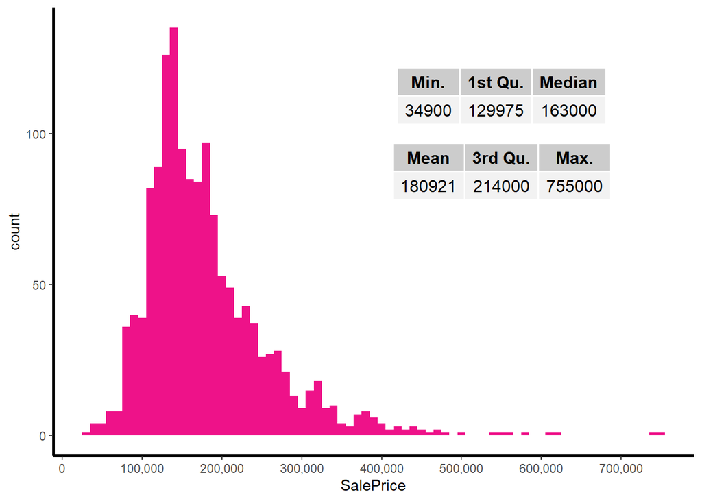

```r
all %>%
  filter(!(is.na(SalePrice))) %>%
  ggplot(aes(x = SalePrice )) +
  geom_histogram(fill="deeppink2",
                 binwidth = 10000) +
  scale_x_continuous(breaks= seq(0, 800000, by=100000),
                     labels = comma)+
  theme_bw() + #去掉背景色
  theme(panel.grid=element_blank(),  #去掉網線
        panel.border=element_blank(),#去掉邊線
        axis.line=element_line(size=1,colour="black")) +
  annotation_custom(tableGrob(summary(all$SalePrice) %>%
                                "["(1:3) %>% as.matrix() %>%
                                t,rows = NULL),
                    xmin=400000, xmax=700000,
                    ymin=75, ymax=150)+
  annotation_custom(tableGrob(summary(all$SalePrice) %>%
                                round() %>%
                                "["(4:6) %>%
                                as.matrix() %>%
                                t,rows = NULL),
                    xmin=400000, xmax=700000,
                    ymin=75, ymax=100)
```

## 數值變數和目標變數的相關性

探索資料第二個步驟就是觀察各個變數和目標變數之間的相關性了，好讓我之後特徵工程比較好處理。

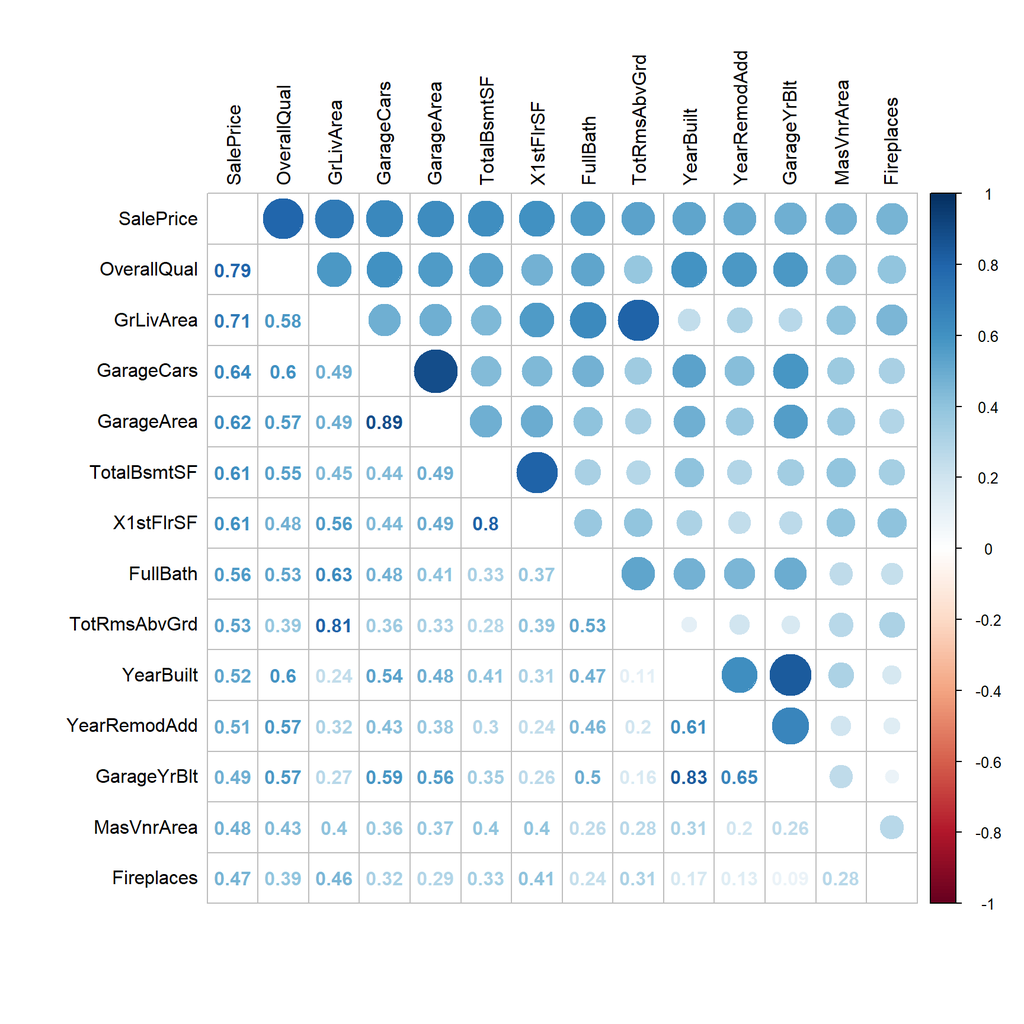

```r
cor_numvar <- cor(all[, num_var],
                  use="pairwise.complete.obs")
#排序之後挑出去相關性絕對值大於0.4的
cor_sortname <-
  sort(cor_numvar[,'SalePrice'],
       decreasing = TRUE) %>%
  as.matrix() %>%
  apply(1, function(x) abs(x)>0.4) %>%
  which() %>%
  names()
cor_numvar_sort <- cor_numvar[cor_sortname, cor_sortname]
#相關性視覺化
corrplot.mixed(cor_numvar_sort, tl.col="black", tl.pos = "lt")
```

透過上圖，相關性大於0.5的變數大概有10個、大於0.7則有兩個(OverallQual & GrLivArea)。後面剩餘的相關性章節我會再獨立出OverallQual & GrLivArea這兩個高相關性變數來個別視覺化其和目標變數的關係。

另外，變數間的共線性問題也要處理。例如GargeCars和GargeArea(0.89)、X1stFlrSF和TotalBsmtSF(0.8)、TotRmsAbvGrd和GrLivArea(0.81)、GarageYrBlt和YearBuilt(0.83)等等，這些會在後面特徵工程的部分進行處理。

## OverallQual

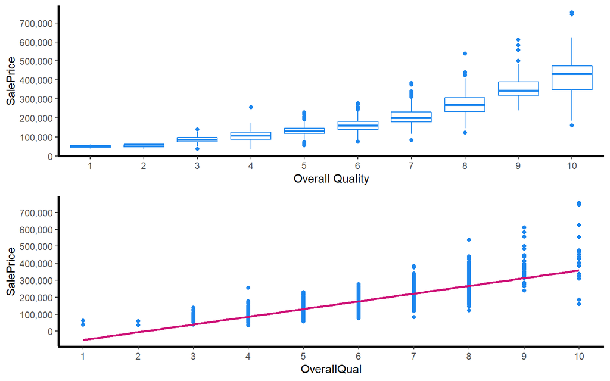

```r
grid.arrange(all %>% filter(!(is.na(SalePrice))) %>%
              ggplot(aes(x=factor(OverallQual), y=SalePrice))+
              geom_boxplot(col='dodgerblue2') +
              labs(x='Overall Quality') +
              scale_y_continuous(breaks= seq(0, 800000, by=100000),
                                 labels = comma)+
              GGvisualize_theme(),
             all %>% filter(!(is.na(SalePrice))) %>%
              ggplot(aes(x=OverallQual, y=SalePrice))+
              geom_point(col='dodgerblue2') +
              geom_smooth(method = "lm", se=FALSE, color="deeppink3") +
              scale_x_continuous(breaks = seq(1,10,1))+
              scale_y_continuous(breaks= seq(0, 800000, by=100000),
                                 labels = comma)+
              GGvisualize_theme())
```

OverallQual和銷售價格明顯的呈現正相關，而且OverallQual越高銷售價格距離也越大(離散程度)。從箱型圖上看來，沒有差異很大的離群值要踢掉，比較明顯的大概是OverallQual第4和第10。

## GrLivArea

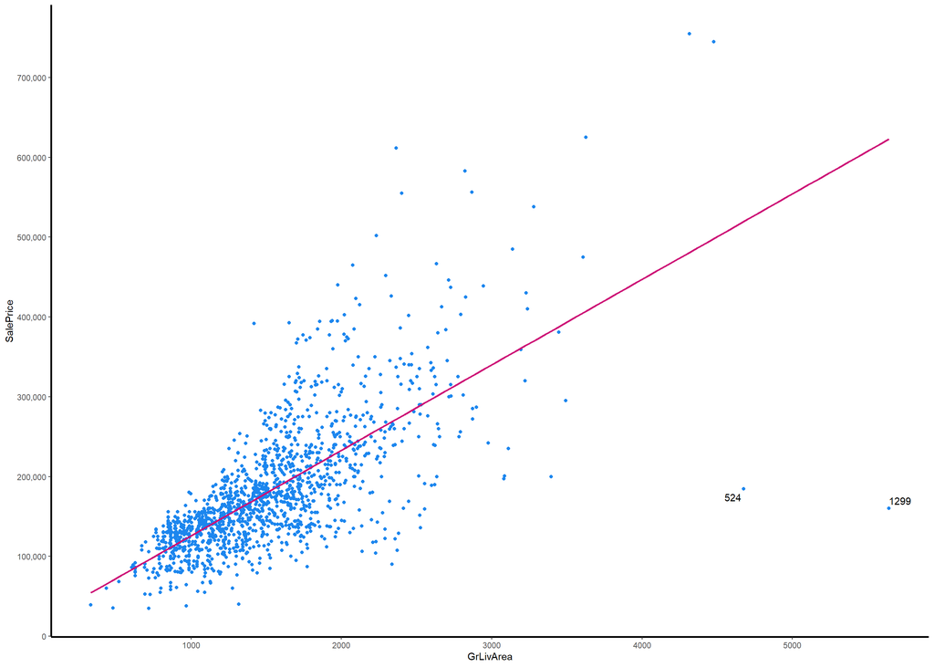

```r
all %>%
  filter(!(is.na(SalePrice))) %>%
  ggplot(aes(x=GrLivArea, y=SalePrice))+
  geom_point(col='dodgerblue2') +
  geom_smooth(method = "lm", se=FALSE, color="deeppink3") +
  scale_y_continuous(breaks= seq(0, 800000, by=100000),
                     labels = comma) +
  geom_text_repel(aes(label = ifelse(all$GrLivArea[!is.na(all$SalePrice)]>4500,
                                     rownames(all), "")))+
               GGvisualize_theme()
```

```r
#觀察outlier
all[c(524, 1299), c('SalePrice', 'GrLivArea', 'OverallQual')]
```

```
##      SalePrice GrLivArea OverallQual
## 524     184750      4676          10
## 1299    160000      5642          10
```

524和1299這對兄弟超奇怪的，OverallQual的分數為10、GrLivArea又是屬於前段班，照理來說房價應該會貴到天際才對。但是我在這邊暫時先不會踢掉這兩筆資料，他們會列入可疑名單並在後續特徵工程的時候會再拿出來討論，畢竟貿然地踢掉資料是一個奢侈又高風險的行為。

## 觀察NA值

來看看哪些變數包含NA值。

```r
na_col <-
  all[is.na(all) %>% colSums %>% ">"(0) %>% which] %>%
  sapply(is.na) %>%
  colSums() %>%
  sort(decreasing = TRUE)
na_col
```

```
##       PoolQC  MiscFeature        Alley        Fence    SalePrice  FireplaceQu
##         2909         2814         2721         2348         1459         1420
##  LotFrontage  GarageYrBlt GarageFinish   GarageQual   GarageCond   GarageType
##          486          159          159          159          159          157
##     BsmtCond BsmtExposure     BsmtQual BsmtFinType2 BsmtFinType1   MasVnrType
##           82           82           81           80           79           24
##   MasVnrArea     MSZoning    Utilities BsmtFullBath BsmtHalfBath   Functional
##           23            4            2            2            2            2
##  Exterior1st  Exterior2nd   BsmtFinSF1   BsmtFinSF2    BsmtUnfSF  TotalBsmtSF
##            1            1            1            1            1            1
##   Electrical  KitchenQual   GarageCars   GarageArea     SaleType
##            1            1            1            1            1
```

我將會在後面特徵工程時連同重新編碼、轉換變數時一併處理NA值。

# 特徵工程

## 資料清洗

### 疑漏值處理

我會在這邊進行遺漏值NA的處理，也會連帶處理跟具有NA變數相關的變數群。

#### Pool

```r
na_col[names(na_col) %>% str_detect("Pool") %>% which]
```

```
## PoolQC
##   2909
```

##### PoolQC

2909個NA  
PoolQC: Pool quality

- Ex Excellent
- Gd Good
- TA Average/Typical
- Fa Fair
- NA No Pool

```r
all$PoolQC[is.na(all$PoolQC)] <- 'None'
all$PoolQC<-as.integer(plyr::revalue(all$PoolQC,
                                     c('None' = 0, 'Po' = 1,
                                       'Fa' = 2, 'TA' = 3,
                                       'Gd' = 4, 'Ex' = 5)))
table(all$PoolQC)
```

```
##
##    0    2    4    5
## 2909    2    4    4
```

```r
all[all$PoolQC != 0,c("SalePrice","PoolQC","PoolArea","OverallQual")]
```

```
##      SalePrice PoolQC PoolArea OverallQual
## 198     235000      5      512           8
## 811     181000      2      648           6
## 1171    171000      4      576           6
## 1183    745000      5      555          10
## 1299    160000      4      480          10
## 1387    250000      2      519           7
## 1424    274970      4      738           6
## 1975        NA      5      144          10
## 2574        NA      5      228           8
## 2711        NA      4      800           7
```

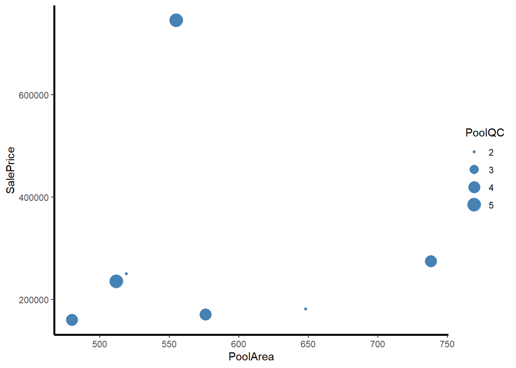

```r
all %>%
  filter(!(is.na(SalePrice)) & PoolQC != 0) %>%
  ggplot(aes(x = PoolArea,
             y = SalePrice ,
             size = PoolQC
             )) +
  geom_point(color = "steelblue") +
               GGvisualize_theme()
```

##### PoolArea

另一個跟Pool有關的是PoolArea:

```r
table(all$PoolArea != 0 )
```

```
##
## FALSE  TRUE
##  2906    13
```

竟然有13個值(PoolQC只有10個)。

```r
all[all$PoolArea>0 & all$PoolQC == 0, c('SalePrice','PoolArea', 'PoolQC', 'OverallQual')]
```

```
##      SalePrice PoolArea PoolQC OverallQual
## 2421        NA      368      0           4
## 2504        NA      444      0           6
## 2600        NA      561      0           3
```

這三個疑似缺漏值的資料出現在要預測的資料集裡面，我們也不能隨便亂刪掉，只好透過觀察現有的10筆資料來填補PoolQC回去。

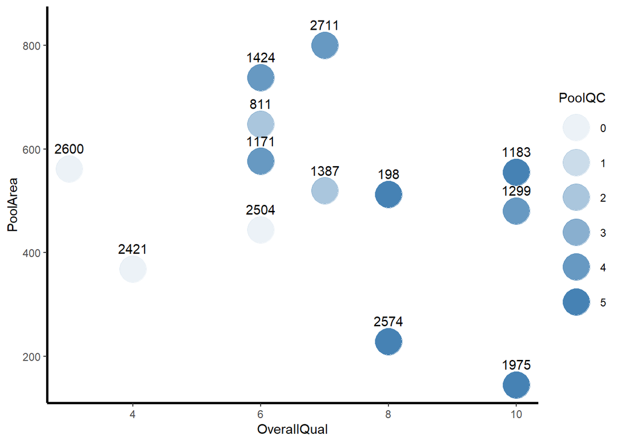

```r
all[all$PoolArea > 0,] %>%
  ggplot(aes(x = OverallQual,y = PoolArea)) +
  geom_point(aes(alpha = PoolQC),
             size = 10,color = 'steelblue') +
  geom_text(aes(label = ifelse(all[all$PoolArea > 0,"PoolArea"]> 0,
                               rownames(all[all$PoolArea > 0,]),
                               "")),nudge_y = 40)  +
  GGvisualize_theme()
```

透過上圖我會把這三個值都填2回去比較合理。

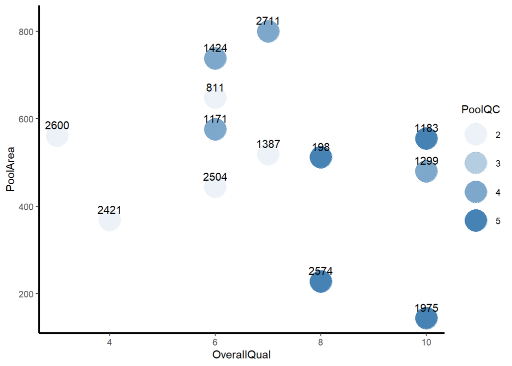

```r
all$PoolQC[c(2421,2504,2600)] <- 2

all[all$PoolArea > 0,] %>%
  ggplot(aes(x = OverallQual,y = PoolArea)) +
  geom_point(aes(alpha = PoolQC),
             size = 10,color = 'steelblue') +
  geom_text(aes(label = ifelse(all[all$PoolArea > 0,"PoolArea"]> 0,
                               rownames(all[all$PoolArea > 0,]),
                               "")),nudge_y = 25)  +
  GGvisualize_theme()
```

#### Miscellaneous Feature

```r
names(all)[names(all) %>% str_detect("Mis") %>% which]
```

```
## [1] "MiscFeature" "MiscVal"
```

```r
na_col[names(na_col) %>% str_detect("Mis") %>% which]
```

```
## MiscFeature
##        2814
```

2814個NA MiscFeature: Miscellaneous feature not covered in other categories

- Elev Elevator
- Gar2 2nd Garage (if not described in garage section)
- Othr Other
- Shed Shed (over 100 SF)
- TenC Tennis Court
- NA None

轉成factor。

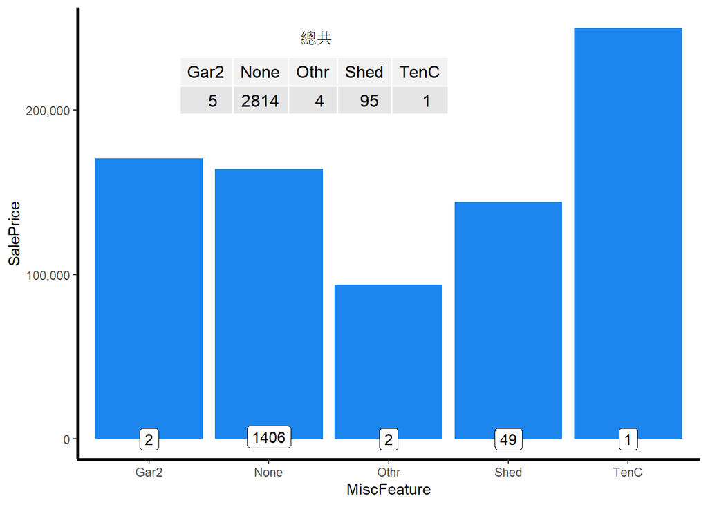

```r
all$MiscFeature[is.na(all$MiscFeature)] <- "None"
all$MiscFeature <- as.factor(all$MiscFeature)
all %>%
  filter(!(is.na(SalePrice))) %>%
  ggplot(aes(x=MiscFeature, y=SalePrice)) +
  stat_summary(geom ='bar', fun = "median", fill='dodgerblue2') +
  scale_y_continuous(breaks= seq(0, 800000, by=100000), labels = comma) +
  geom_label(stat = "count", aes(label = ..count.., y = ..count..)) +
  GGvisualize_theme() +
  annotate('text',x = 2.4,y = 245000,label = '總共')+
  annotation_custom(tableGrob(table(all$MiscFeature) %>% as.data.frame()%>% t ,
                              rows = NULL),
                    xmin=0.75, xmax=4,
                    ymin=180000, ymax=250000)
```

看起來MiscFeature這類別變數沒甚麼相關，絕大多數都是None居多。第二多的shed也沒有明顯和None有差異，差異比較大的TenC和Othr佔的件數又少很多。

##### MiscVal

驗證一下是否有MiscVal有值而MiscFeature是None，或是MiscVal為0而MiscFeature不是None的情況發生。

```r
all %>%
  filter(!(MiscFeature %in% "None") & MiscVal == 0) %>%
  select("Id","MiscVal","MiscFeature","SalePrice")
```

```
##     Id MiscVal MiscFeature SalePrice
## 1  874       0        Othr    133000
## 2 1201       0        Shed    116050
## 3 2432       0        Shed        NA
```

```r
all %>%
  filter(MiscFeature %in% "None" & MiscVal != 0) %>%
  select("Id","MiscVal","MiscFeature","SalePrice")
```

```
##     Id MiscVal MiscFeature SalePrice
## 1 2550   17000        None        NA
```

這三筆資料我不會去更動它，因為我並不知道價值為0是因為誤植還是它真的就是免費大贈送的。至於2550這筆就奇怪了，MiscFeature為None但是MiscVal卻高達17000，觀察一下MiscVal和MiscFeature的交叉分布。

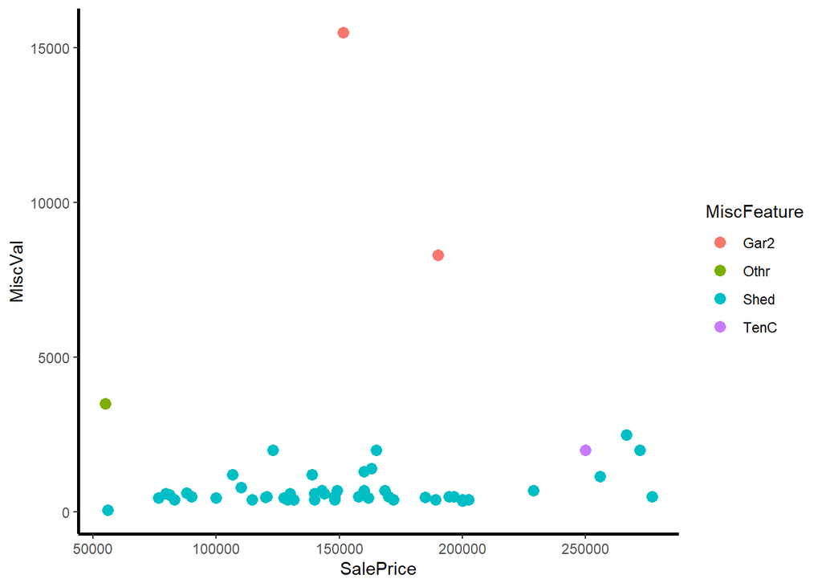

```r
all %>%
  filter(!(is.na(SalePrice)),MiscVal != 0) %>%
  ggplot(aes(x = SalePrice,y = MiscVal,color = MiscFeature)) +
  geom_point(size = 3) +
  GGvisualize_theme()
```

根據圖形我會將2550的MiscFeature改為Gar2

```r
all[2550,'MiscFeature'] <- 'Gar2'
```

#### Alley

2721個NA Alley: Type of alley access to property

- Grvl Gravel
- Pave Paved
- NA No alley access

轉成factor。

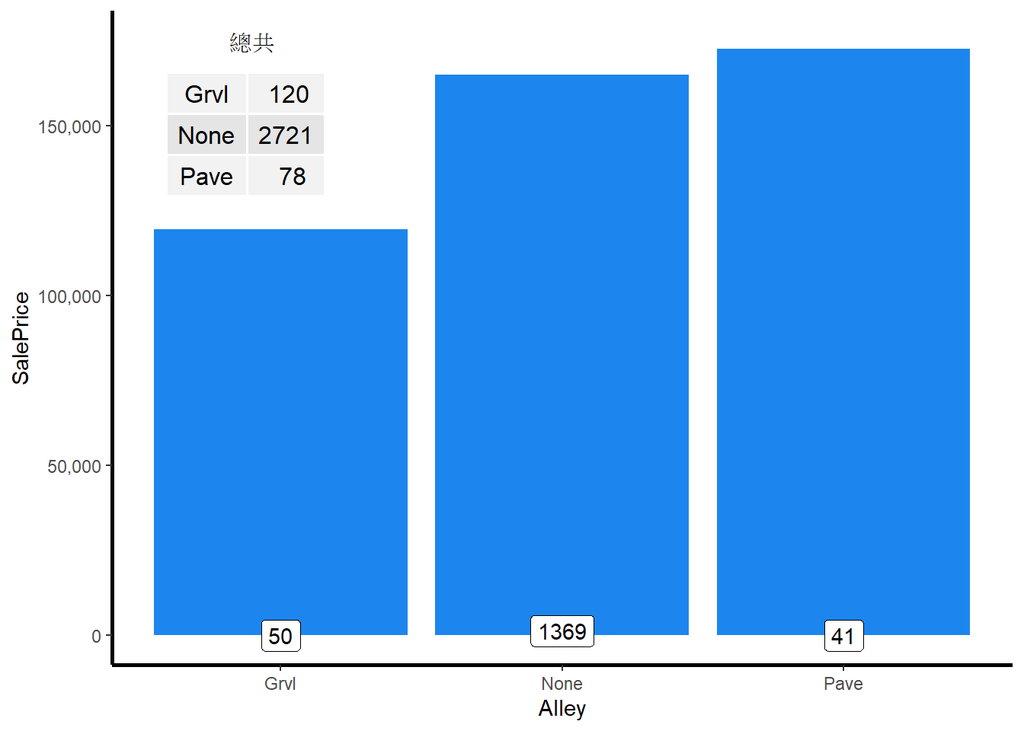

```r
all$Alley[is.na(all$Alley)] <- 'None'
all$Alley %<>% as.factor()
all %>%
  filter(!(is.na(SalePrice))) %>%
  ggplot(aes(x=Alley, y=SalePrice)) +
  stat_summary(geom ='bar', fun = "median", fill='dodgerblue2')+
  scale_y_continuous(breaks= seq(0, 200000, by=50000), labels = comma) +
  geom_label(stat = "count",aes(label = ..count..,y = ..count..)) +
  GGvisualize_theme() +
  annotate('text',x = 0.9 ,y = 175000  ,label = '總共')+
  annotation_custom(tableGrob(table(all$Alley) %>% as.data.frame() ,
                              rows = NULL,cols = NULL),
                    xmin=0.25, xmax = 1.5,
                    ymin=120000, ymax=175000)
```

#### Fence

2348個NA Fence: Fence quality

- GdPrv Good Privacy
- MnPrv Minimum Privacy
- GdWo Good Wood
- MnWw Minimum Wood/Wire
- NA No Fence

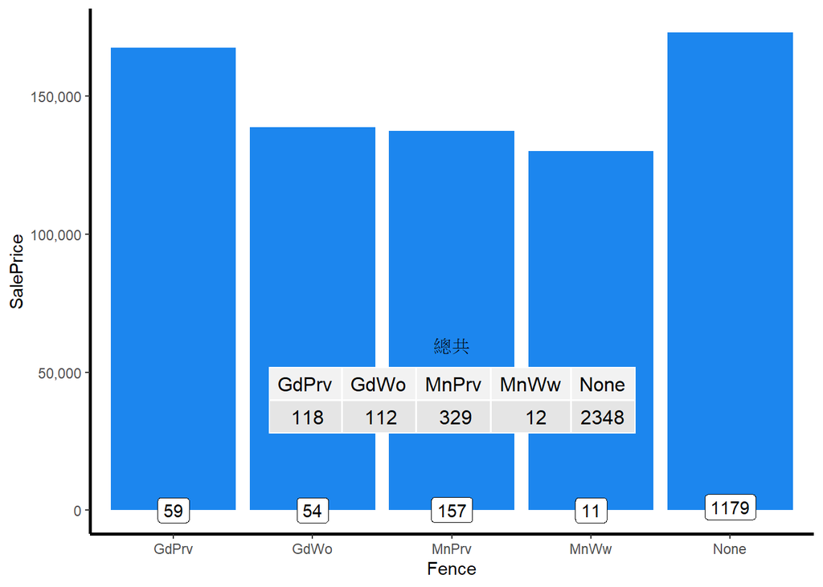

```r
all$Fence[is.na(all$Fence)] <- 'None'
all %>%
  filter(!(is.na(SalePrice))) %>%
  ggplot(aes(x=Fence, y=SalePrice)) +
  stat_summary(geom ='bar', fun = "median", fill='dodgerblue2')+
  scale_y_continuous(labels = comma) +
  geom_label(stat = "count",aes(label = ..count..,y = ..count..)) +
  GGvisualize_theme() +
  annotate('text',x = 3 ,y = 60000  ,label = '總共')+
  annotation_custom(tableGrob(table(all$Fence) %>% as.data.frame() %>% t() ,rows = NULL),
                    xmin=1.5, xmax = 4.5,
                    ymin=5000, ymax=75000)
```

```r
all$Fence <- as.factor(all$Fence)
```

看起來沒有明顯的次序關係，沒有Fence的房屋價格比較高，所以轉成factor。

#### Fireplace

```r
names(all)[names(all) %>% str_detect("Fireplace") %>% which]
```

```
## [1] "Fireplaces"  "FireplaceQu"
```

```r
na_col[names(na_col) %>% str_detect("Fireplace") %>% which]
```

```
## FireplaceQu
##        1420
```

##### FireplaceQu

1420個NA * Ex Excellent - Exceptional Masonry Fireplace * Gd Good - Masonry Fireplace in main level * TA Average - Prefabricated Fireplace in main living area or Masonry Fireplace in basement  
* Fa Fair - Prefabricated Fireplace in basement * Po Poor - Ben Franklin Stove * NA No Fireplace

像這種在變數說明或者常理上能夠認知是有次序的，我都會把他轉成數值。

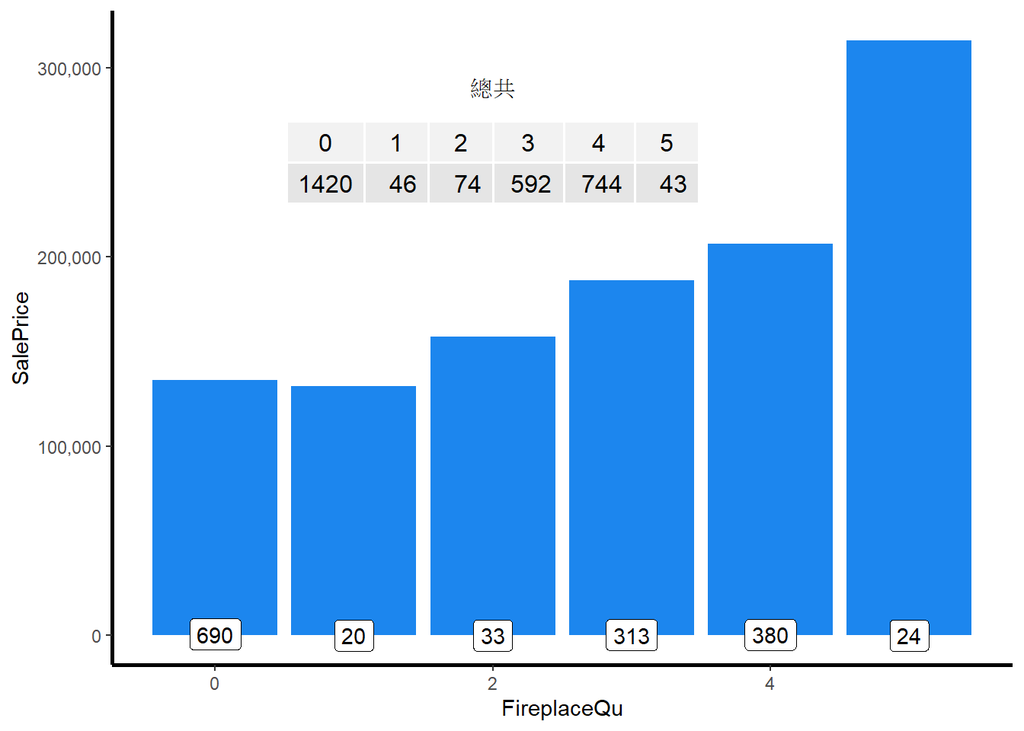

```r
all$FireplaceQu[is.na(all$FireplaceQu)] <- 'None'
all$FireplaceQu<-as.integer(plyr::revalue(all$FireplaceQu,
                                          c('None' = 0, 'Po' = 1,
                                            'Fa' = 2, 'TA' = 3,
                                            'Gd' = 4, 'Ex' = 5)))
all %>%
  filter(!(is.na(SalePrice))) %>%
  ggplot(aes(x = FireplaceQu, y = SalePrice)) +
  stat_summary(geom ='bar', fun = "median", fill='dodgerblue2')+
  scale_y_continuous(labels = comma) +
  geom_label(stat = "count",aes(label = ..count..,y = ..count..)) +
  GGvisualize_theme() +
  annotate('text',x = 2 ,y = 290000  ,label = '總共')+
  annotation_custom(tableGrob(table(all$FireplaceQu) %>% as.data.frame() %>% t() ,
                              rows = NULL),
                    xmin=0, xmax = 4,
                    ymin=220000, ymax=280000)
```

##### Fireplaces

```r
table(all$Fireplaces)
```

```
##
##    0    1    2    3    4
## 1420 1268  219   11    1
```

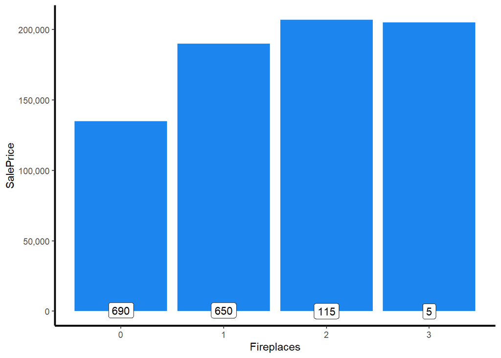

```r
all %>%
  filter(!(is.na(SalePrice))) %>%
  ggplot(aes(x = Fireplaces, y = SalePrice)) +
  stat_summary(geom ='bar', fun = "median", fill='dodgerblue2')+
  scale_y_continuous(labels = comma) +
  geom_label(stat = "count",aes(label = ..count..,y = ..count..)) +
  GGvisualize_theme()
```

#### Lot

```r
names(all)[names(all) %>% str_detect("Lot") %>% which]
```

```
## [1] "LotFrontage" "LotArea"     "LotShape"    "LotConfig"
```

```r
na_col[names(na_col) %>% str_detect("Lot") %>% which]
```

```
## LotFrontage
##         486
```

##### LotFrontage

LotFrontage: Linear feet of street connected to property 486個NA 初步建模我先根據房屋所在地區的中位數來填補。為什麼呢？拿台灣來說吧，嘉義縣的房子大部分來說要到街上肯定比台北市的房子去到街上還要遠，這就是郊區跟市區的差別。但是這樣還是會有偏誤，以台北市來說北投區內湖區有可能會比中正區信義區還要來的遠，也就是說城市內部也會存在著很大的差異。下一次我有可能會針對這個變數單獨建一個模型來估計它的遺漏值。

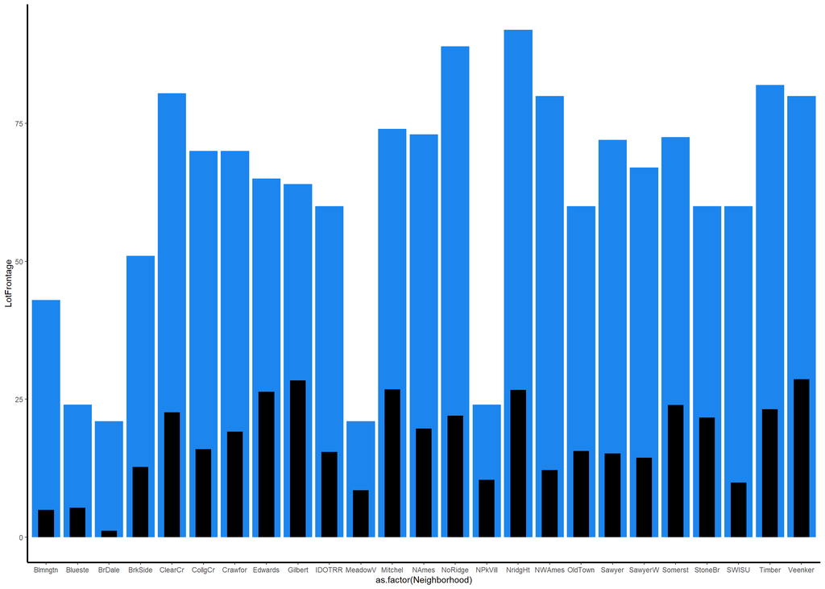

```r
all %>%
  ggplot( aes(x=as.factor(Neighborhood), y=LotFrontage)) +
  stat_summary(geom ='bar', fun = "median", fill='dodgerblue2') +
  stat_summary(geom ='bar', fun = "sd", fill='black',width = 0.5) +
  GGvisualize_theme()
```

藍色是中位數，黑色是標準差。從圖上可以看出部分城鎮跟城鎮以及區域跟區域之間存在著上述所講的差異。

```r
#利用dplyr結合ifelse進行向量式填補
all %<>%
  group_by(Neighborhood) %>%
  mutate(LotFrontage = ifelse(is.na(LotFrontage),
                              median(LotFrontage,na.rm = T),
                              LotFrontage)) %>%
  as.data.frame()
```

##### LotShape

沒有NA

- Reg Regular
- IR1 Slightly irregular
- IR2 Moderately Irregular
- IR3 Irregular

看起來應該是有次序的變數，但是視覺化後卻不是這樣。

```r
table(all$LotShape)
```

```
##
##  IR1  IR2  IR3  Reg
##  968   76   16 1859
```

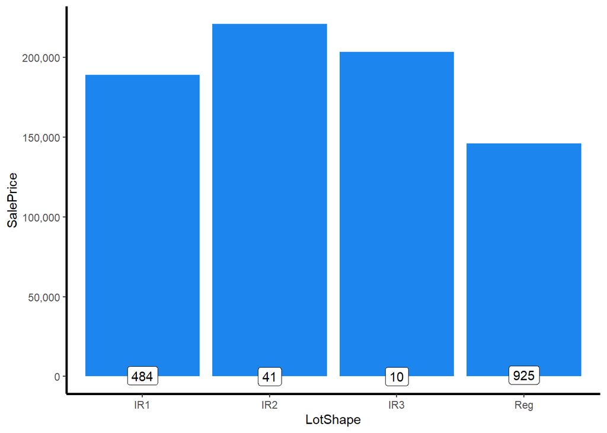

```r
#將其轉換為數字
all %>%
  filter(!(is.na(SalePrice))) %>%
  ggplot( aes(x=LotShape, y=SalePrice)) +
  stat_summary(geom ='bar', fun = "median", fill='dodgerblue2') +
  scale_y_continuous(labels = comma) +
  geom_label(stat = "count",aes(label = ..count..,y = ..count..))+
  GGvisualize_theme()
```

```r
#轉為factor
all$LotShape %<>% as.factor()
```

##### LotConfig

沒有NA

- Inside Inside lot
- Corner Corner lot
- CulDSac Cul-de-sac
- FR2 Frontage on 2 sides of property
- FR3 Frontage on 3 sides of property

應該不是有次序的變數，把它轉成factor。

```r
all$LotConfig %<>% as.factor()
table(all$LotConfig)
```

```
##
##  Corner CulDSac     FR2     FR3  Inside
##     511     176      85      14    2133
```

#### Garage

```r
names(all)[names(all) %>% str_detect("Garage") %>% which]
```

```
## [1] "GarageType"   "GarageYrBlt"  "GarageFinish" "GarageCars"   "GarageArea"
## [6] "GarageQual"   "GarageCond"
```

```r
na_col[names(na_col) %>% str_detect("Garage") %>% which]
```

```
##  GarageYrBlt GarageFinish   GarageQual   GarageCond   GarageType   GarageCars
##          159          159          159          159          157            1
##   GarageArea
##            1
```

##### GarageYrBlt

GarageYrBlt: Year garage was built

這邊我會將車庫建造年的NA值改成YearBuilt的年份,NA值有可能是因為該房子沒有車庫,改成YearBuilt的理由類似YearRemodAdd.在說明文件裡面YearRemodAdd: Remodel date (same as construction date if no remodeling or additions).

```r
all$GarageYrBlt[is.na(all$GarageYrBlt)] <- all$YearBuilt[is.na(all$GarageYrBlt)]
```

##### GarageCars & GarageArea

```r
all[!is.na(all$GarageType) & is.na(all$GarageFinish),
    c('GarageCars', 'GarageArea', 'GarageType',
      'GarageCond', 'GarageQual', 'GarageFinish')]
```

```
##      GarageCars GarageArea GarageType GarageCond GarageQual GarageFinish
## 2127          1        360     Detchd       <NA>       <NA>         <NA>
## 2577         NA         NA     Detchd       <NA>       <NA>         <NA>
```

看起來2127似乎是有車庫,2577沒有,那就把2577改成沒有車庫,2127的GarageCond GarageQual GarageFinish的三個NA值改成該變數最多的值

```r
all$GarageCond[2127] <- names(sort(-table(all$GarageCond)))[1]
all$GarageQual[2127] <- names(sort(-table(all$GarageQual)))[1]
all$GarageFinish[2127] <- names(sort(-table(all$GarageFinish)))[1]
all[2127,
    c('GarageYrBlt', 'GarageCars', 'GarageArea',
      'GarageType', 'GarageCond', 'GarageQual', 'GarageFinish')]
```

```
##      GarageYrBlt GarageCars GarageArea GarageType GarageCond GarageQual
## 2127        1910          1        360     Detchd         TA         TA
##      GarageFinish
## 2127          Unf
```

```r
#修改2577
all$GarageCars[2577] <- 0
all$GarageArea[2577] <- 0
all$GarageType[2577] <- NA

#這樣就讓剩下Garage NA一致了
all[,str_detect(names(all),"Garage")] %>%
  sapply(is.na) %>%
  colSums() %>%
  "["(.!=0)
```

```
##   GarageType GarageFinish   GarageQual   GarageCond
##          158          158          158          158
```

##### GarageType

- 2Types More than one type of garage
- Attchd Attached to home
- Basment Basement Garage
- BuiltIn Built-In (Garage part of house - typically has room above garage)
- CarPort Car Port
- Detchd Detached from home
- NA No Garage

```r
all$GarageType[is.na(all$GarageType)] <- 'No Garage'
all$GarageType <- as.factor(all$GarageType)
table(all$GarageType)
```

```
##
##    2Types    Attchd   Basment   BuiltIn   CarPort    Detchd No Garage
##        23      1723        36       186        15       778       158
```

##### GarageFinish

- Fin Finished
- RFn Rough Finished
- Unf Unfinished
- NA No Garage

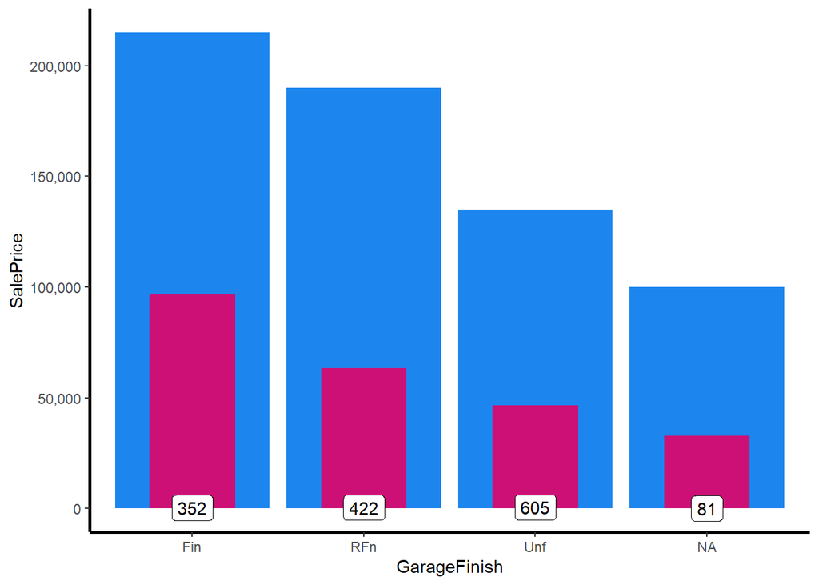

```r
all %>%
  filter(!(is.na(SalePrice))) %>%
  ggplot( aes(x=GarageFinish, y=SalePrice)) +
  stat_summary(geom ='bar', fun = "median", fill='dodgerblue2') +
  stat_summary(geom ='bar', fun = "sd", fill='deeppink3',width = 0.5) +
  scale_y_continuous(labels = comma) +
  geom_label(stat = "count",aes(label = ..count..,y = ..count..)) +
  GGvisualize_theme()
```

```r
all$GarageFinish[is.na(all$GarageFinish)] <- 'None'
all$GarageFinish <- as.integer(plyr::revalue(all$GarageFinish,
                                             c('None'=0, 'Unf'=1,
                                               'RFn'=2, 'Fin'=3)))
table(all$GarageFinish)
```

```
##
##    0    1    2    3
##  158 1231  811  719
```

暗紅色代表標準差，明顯的次序關係我就將其轉成數字。

##### GarageQual

- Ex Excellent
- Gd Good
- TA Typical/Average
- Fa Fair
- Po Poor
- NA No Garage

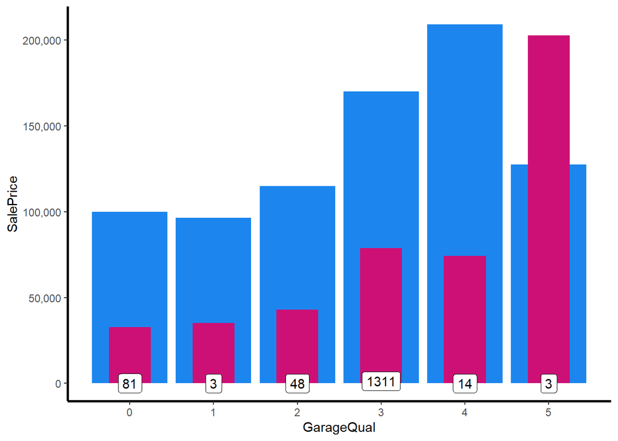

```r
all$GarageQual[is.na(all$GarageQual)] <- 'None'
all$GarageQual <-
  as.integer(plyr::revalue(all$GarageQual, c('None' = 0, 'Po' = 1, 'Fa' = 2,
                                             'TA' = 3,'Gd' = 4, 'Ex' = 5)))
all %>%
  filter(!(is.na(SalePrice))) %>%
  ggplot( aes(x=GarageQual, y=SalePrice)) +
  stat_summary(geom ='bar', fun = "median", fill='dodgerblue2') +
  stat_summary(geom ='bar', fun = "sd", fill='deeppink3',width = 0.5) +
  scale_x_continuous(breaks = seq(min(all$GarageQual),max(all$GarageQual))) +
  scale_y_continuous(labels = comma) +
  geom_label(stat = "count",aes(label = ..count..,y = ..count..)) +
  GGvisualize_theme()
```

從圖形上可以看出Poor Garge 幾乎跟沒有Garge一樣，感覺沒有Garge可能還比較好。另外Ex Garage數量稀少所以標準差還比中位數大，可見三個物件彼此相異很大。這邊我會把0和1以及4和5合併增加這個變數的可解釋性。

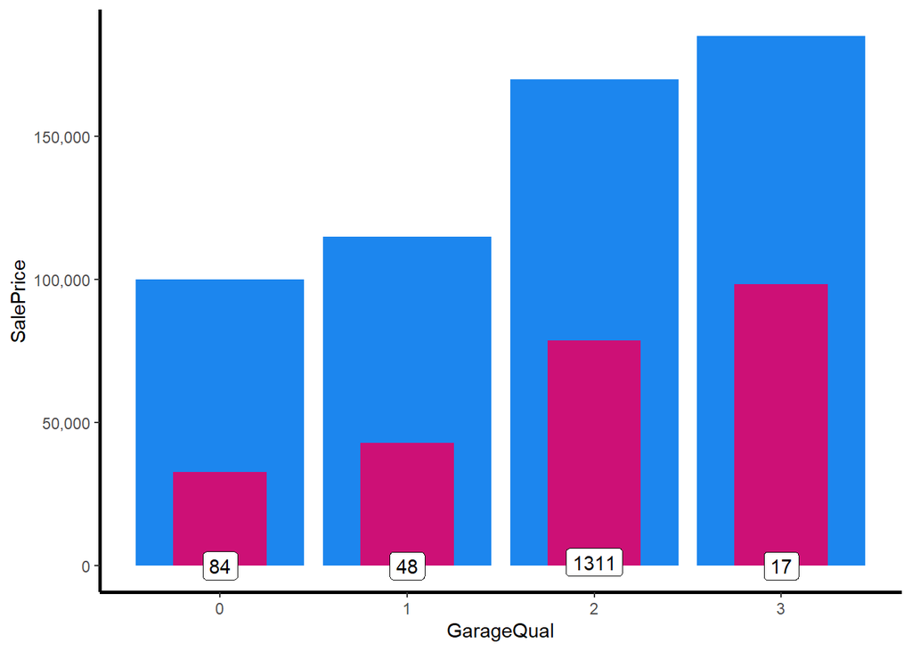

```r
all$GarageQual <- ifelse(all$GarageQual %in% c(0:1),0,
                         ifelse(all$GarageQual %in% c(4:5),3,all$GarageQual - 1))
all %>%
  filter(!(is.na(SalePrice))) %>%
  ggplot( aes(x=GarageQual, y=SalePrice)) +
  geom_bar(stat = 'summary', fun = "median", fill = 'dodgerblue2') +
  geom_bar(stat = 'summary', fun = "sd", fill = 'deeppink3',width = 0.5) +
  scale_y_continuous(labels = comma) +
  geom_label(stat = "count",aes(label = ..count..,y = ..count..))  +
  GGvisualize_theme()
```

##### GarageCond

- Ex Excellent
- Gd Good
- TA Typical/Average
- Fa Fair
- Po Poor
- NA No Garage

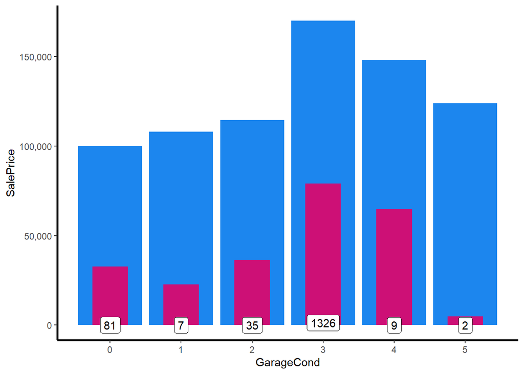

```r
all$GarageCond[is.na(all$GarageCond)] <- 'None'
all$GarageCond <-
  as.integer(plyr::revalue(all$GarageCond,
                           c('None' = 0, 'Po' = 1, 'Fa' = 2,
                             'TA' = 3,'Gd' = 4, 'Ex' = 5)))
all %>%
  filter(!(is.na(SalePrice))) %>%
  ggplot( aes(x=GarageCond, y=SalePrice)) +
  stat_summary(geom ='bar', fun = "median", fill='dodgerblue2') +
  stat_summary(geom ='bar', fun = "sd", fill='deeppink3',width = 0.5) +
  scale_x_continuous(breaks = seq(min(all$GarageCond),max(all$GarageCond))) +
  scale_y_continuous(labels = comma) +
  geom_label(stat = "count",aes(label = ..count..,y = ..count..))  +
  GGvisualize_theme()
```

#### Basement

```r
na_col[names(na_col) %>% str_detect("Bsmt") %>% which]
```

```
##     BsmtCond BsmtExposure     BsmtQual BsmtFinType2 BsmtFinType1 BsmtFullBath
##           82           82           81           80           79            2
## BsmtHalfBath   BsmtFinSF1   BsmtFinSF2    BsmtUnfSF  TotalBsmtSF
##            2            1            1            1            1
```

總共有11個變數和basement有關,其中有六個變數是只有1-2個NA,5個是79-82,先來統計一下這5個變數都是NA的資料筆數有幾個

```r
length(which(is.na(all$BsmtQual) & is.na(all$BsmtCond) &
             is.na(all$BsmtExposure) & is.na(all$BsmtFinType1) &
             is.na(all$BsmtFinType2)))
```

```
## [1] 79
```

可見會有BsmtFinType1不是NA,而其他四個變數則有NA得情況,我得找出這種情況才行

```r
all[!is.na(all$BsmtFinType1) &
      (is.na(all$BsmtCond)|
       is.na(all$BsmtQual)|
       is.na(all$BsmtExposure)|
       is.na(all$BsmtFinType2)),
    c('BsmtQual', 'BsmtCond', 'BsmtExposure', 'BsmtFinType1', 'BsmtFinType2')]
```

```
##      BsmtQual BsmtCond BsmtExposure BsmtFinType1 BsmtFinType2
## 333        Gd       TA           No          GLQ         <NA>
## 949        Gd       TA         <NA>          Unf          Unf
## 1488       Gd       TA         <NA>          Unf          Unf
## 2041       Gd     <NA>           Mn          GLQ          Rec
## 2186       TA     <NA>           No          BLQ          Unf
## 2218     <NA>       Fa           No          Unf          Unf
## 2219     <NA>       TA           No          Unf          Unf
## 2349       Gd       TA         <NA>          Unf          Unf
## 2525       TA     <NA>           Av          ALQ          Unf
```

這邊的遺漏值我就用眾數來填補.

```r
all$BsmtFinType2[333] <- names(sort(-table(all$BsmtFinType2)))[1]
all$BsmtExposure[c(949, 1488, 2349)] <- names(sort(-table(all$BsmtExposure)))[1]
all$BsmtCond[c(2041, 2186, 2525)] <- names(sort(-table(all$BsmtCond)))[1]
all$BsmtQual[c(2218, 2219)] <- names(sort(-table(all$BsmtQual)))[1]
```

##### BsmtQual

- Ex Excellent (100+ inches)
- Gd Good (90-99 inches)
- TA Typical (80-89 inches)
- Fa Fair (70-79 inches)
- Po Poor (<70 inches
- NA No Basement

```r
all$BsmtQual[is.na(all$BsmtQual)] <- 'None'
table(all$BsmtQual)
```

```
##
##   Ex   Fa   Gd None   TA
##  258   88 1209   79 1285
```

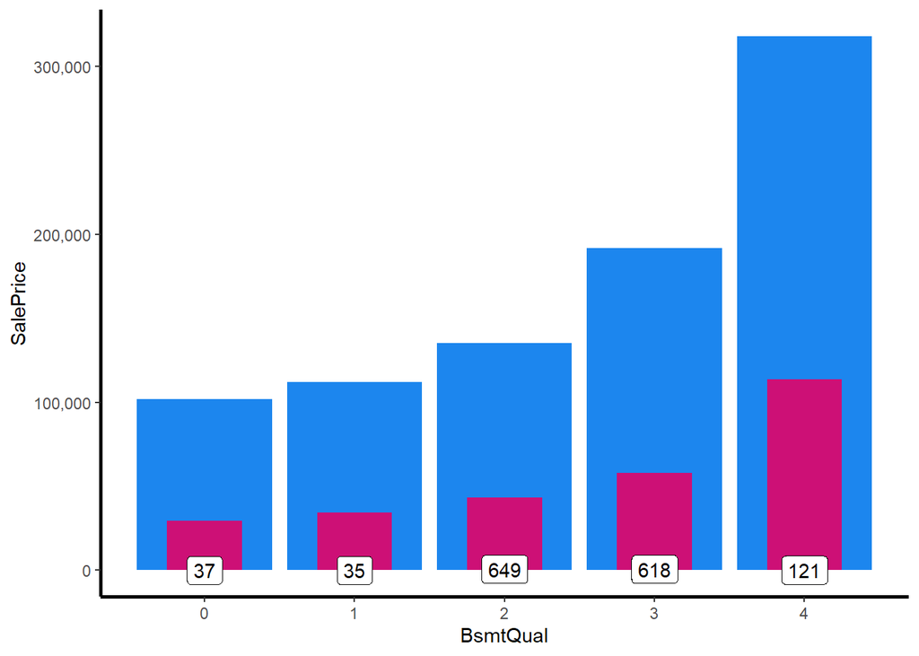

```r
all$BsmtQual <-
  as.integer(plyr::revalue(all$BsmtQual,
             c('None' = 0, 'Fa' = 1,
               'TA' = 2,'Gd' = 3, 'Ex' = 4)))
all %>%
  filter(!(is.na(SalePrice))) %>%
  ggplot( aes(x=BsmtQual, y=SalePrice)) +
  stat_summary(geom ='bar', fun = "median", fill='dodgerblue2') +
  stat_summary(geom ='bar', fun = "sd", fill='deeppink3',width = 0.5) +
  scale_y_continuous(labels = comma) +
  geom_label(stat = "count",aes(label = ..count..,y = ..count..))  +
  GGvisualize_theme()
```

##### BsmtCond

- Ex Excellent
- Gd Good
- TA Typical - slight dampness allowed
- Fa Fair - dampness or some cracking or settling
- Po Poor - Severe cracking, settling, or wetness
- NA No Basement

```r
all$BsmtCond[is.na(all$BsmtCond)] <- 'None'
table(all$BsmtCond)
```

```
##
##   Fa   Gd None   Po   TA
##  104  122   79    5 2609
```

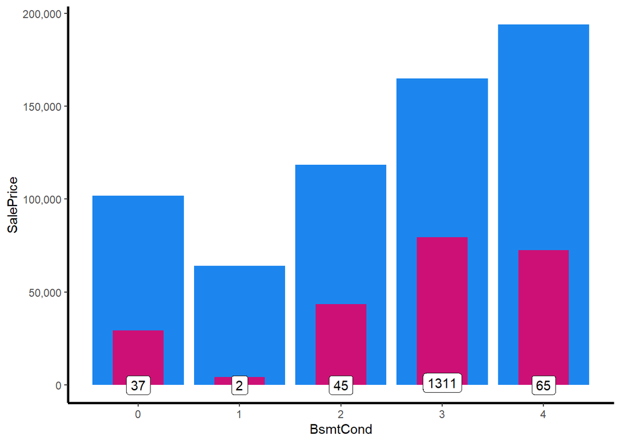

```r
all$BsmtCond <-
  as.integer(plyr::revalue(all$BsmtCond, c('None' = 0, 'Po' = 1, 'Fa' = 2,
                                           'TA' = 3,'Gd' = 4)))
all %>%
  filter(!(is.na(SalePrice))) %>%
  ggplot( aes(x=BsmtCond, y=SalePrice)) +
  stat_summary(geom ='bar', fun = "median", fill='dodgerblue2') +
  stat_summary(geom ='bar', fun = "sd", fill='deeppink3',width = 0.5) +
  scale_y_continuous(labels = comma) +
  geom_label(stat = "count",aes(label = ..count..,y = ..count..))  +
  GGvisualize_theme()
```

##### BsmtExposure

- Gd Good Exposure
- Av Average Exposure (split levels or foyers typically score average or above)
- Mn Mimimum Exposure
- No No Exposure
- NA No Basement

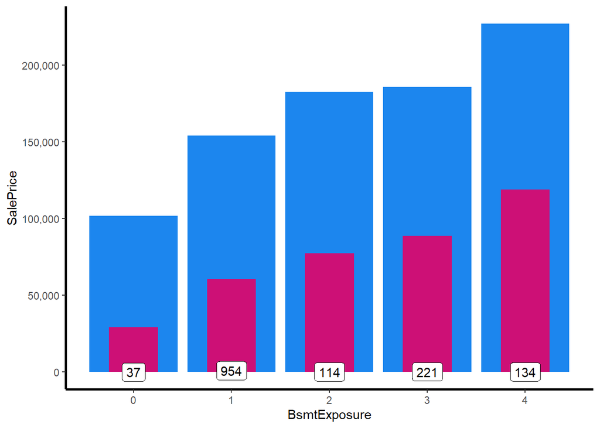

```r
all$BsmtExposure[is.na(all$BsmtExposure)] <- 'None'
all$BsmtExposure <-
  as.integer(plyr::revalue(all$BsmtExposure,
                           c('None'=0, 'No'=1, 'Mn'=2,
                             'Av'=3, 'Gd'=4)))
all %>%
  filter(!(is.na(SalePrice))) %>%
  ggplot( aes(x=BsmtExposure, y=SalePrice)) +
  stat_summary(geom ='bar', fun = "median", fill='dodgerblue2') +
  stat_summary(geom ='bar', fun = "sd", fill='deeppink3',width = 0.5) +
  scale_y_continuous(labels = comma) +
  geom_label(stat = "count",aes(label = ..count..,y = ..count..))  +
  GGvisualize_theme()
```

##### BsmtFinType1

- GLQ Good Living Quarters
- ALQ Average Living Quarters
- BLQ Below Average Living Quarters
- Rec Average Rec Room
- LwQ Low Quality
- Unf Unfinshed
- NA No Basement

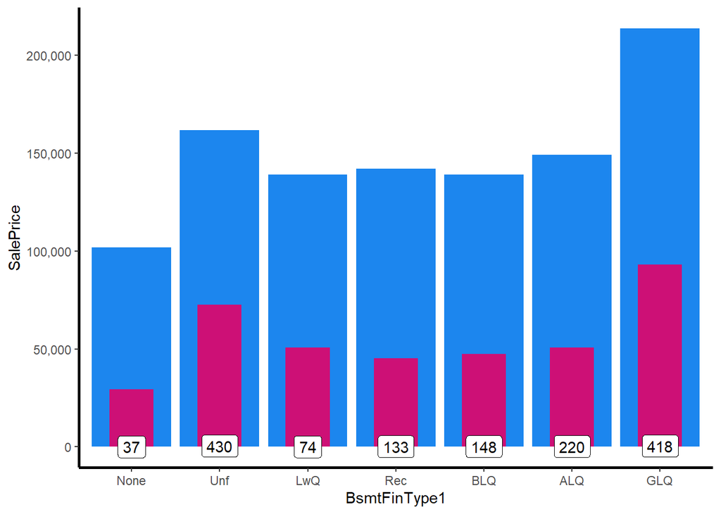

```r
all$BsmtFinType1[is.na(all$BsmtFinType1)] <- 'None'
all %>%
  filter(!(is.na(SalePrice))) %>%
  ggplot( aes(x=factor(BsmtFinType1,levels =c('None', 'Unf', 'LwQ',
                                              'Rec', 'BLQ', 'ALQ','GLQ')),
              y=SalePrice)) +
  stat_summary(geom ='bar', fun = "median", fill='dodgerblue2') +
  stat_summary(geom ='bar', fun = "sd", fill='deeppink3',width = 0.5) +
  scale_y_continuous(labels = comma) +
  xlab('BsmtFinType1') +
  geom_label(stat = "count",aes(label = ..count..,y = ..count..))  +
  GGvisualize_theme()
```

看起來 ‘LwQ’,‘Rec’, ‘BLQ’, ‘ALQ’似乎在售價上面沒甚麼差別，反而Unf還能賣高一點，但是其標準差有點高代表不見得Unf每個物件都能賣高一點。在這邊我會把’LwQ’,‘Rec’, ‘BLQ’, ’ALQ’合併成一個’ABRL’並將這個變數轉為factor。

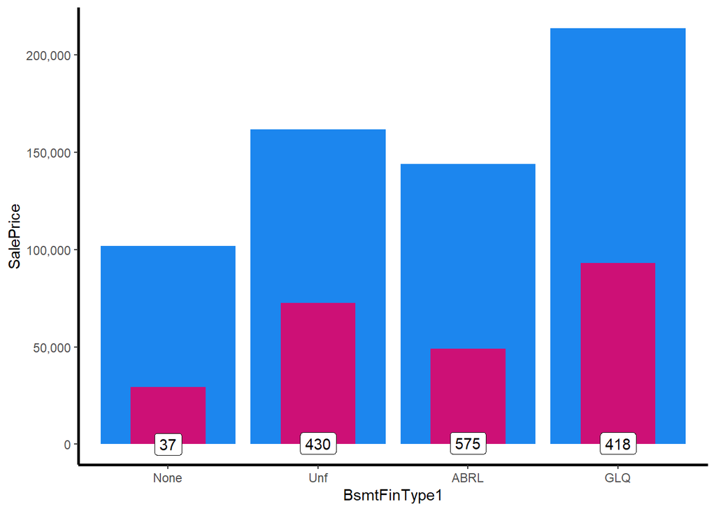

```r
all$BsmtFinType1 <- ifelse(all$BsmtFinType1 %in% c('LwQ','Rec', 'BLQ', 'ALQ'),
                           'ABRL',all$BsmtFinType1)
all$BsmtFinType1 %<>% factor(levels = c('None','Unf','ABRL','GLQ'))
all %>%
  filter(!(is.na(SalePrice))) %>%
  ggplot( aes(x=BsmtFinType1,
              y=SalePrice)) +
  stat_summary(geom ='bar', fun = "median", fill='dodgerblue2') +
  stat_summary(geom ='bar', fun = "sd", fill='deeppink3',width = 0.5) +
  scale_y_continuous(labels = comma) +
  geom_label(stat = "count",aes(label = ..count..,y = ..count..))  +
  GGvisualize_theme()
```

##### BsmtFinType2

- GLQ Good Living Quarters
- ALQ Average Living Quarters
- BLQ Below Average Living Quarters
- Rec Average Rec Room
- LwQ Low Quality
- Unf Unfinshed
- NA No Basement

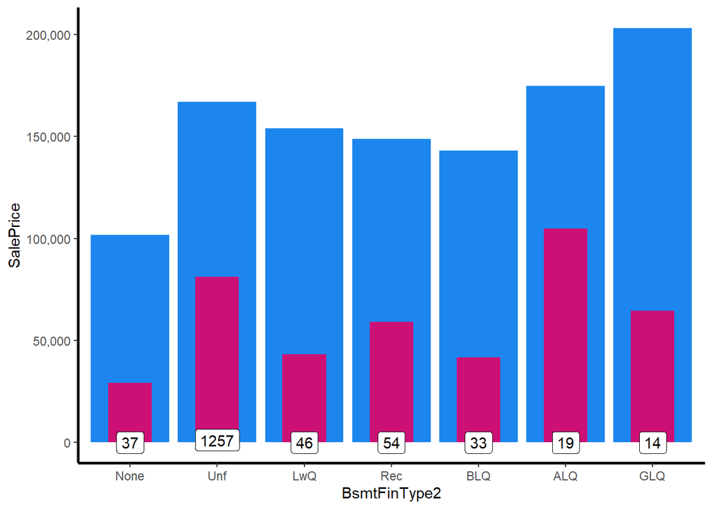

```r
all$BsmtFinType2[is.na(all$BsmtFinType2)] <- 'None'

all %>%
  filter(!(is.na(SalePrice))) %>%
  ggplot( aes(x=factor(BsmtFinType2,levels =c('None', 'Unf', 'LwQ',
                                              'Rec', 'BLQ', 'ALQ','GLQ')),
              y=SalePrice)) +
  stat_summary(geom ='bar', fun = "median", fill='dodgerblue2') +
  stat_summary(geom ='bar', fun = "sd", fill='deeppink3',width = 0.5) +
  scale_y_continuous(labels = comma) +
  xlab('BsmtFinType2') +
  geom_label(stat = "count",aes(label = ..count..,y = ..count..)) +
  GGvisualize_theme()
```

情況跟BsmtFinType1類似，但是ALQ似乎有比較跟’LwQ’,‘Rec’和’BLQ’有明顯的差距，可是其標準差高數量又偏少，感覺組內不夠一致。這邊還是會跟BsmtFinType1處理方法依樣，把’LwQ’,‘Rec’, ‘BLQ’, ’ALQ’合併成一個’ABRL’並將這個變數轉為factor。

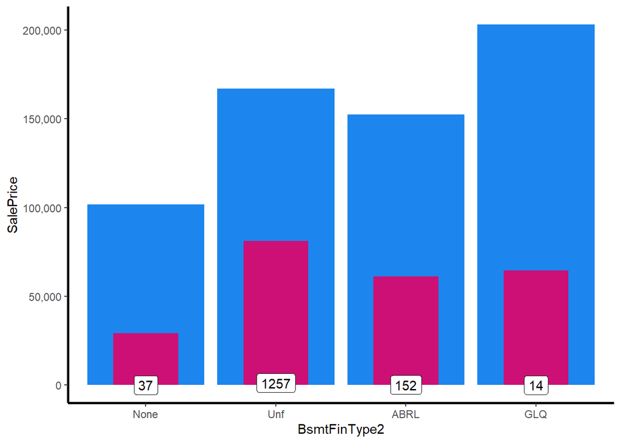

```r
all$BsmtFinType2 <-
  ifelse(all$BsmtFinType2 %in% c('LwQ','Rec', 'BLQ', 'ALQ'),
         'ABRL',all$BsmtFinType2)
all$BsmtFinType2 %<>% factor(levels = c('None','Unf','ABRL','GLQ'))
all %>%
  filter(!(is.na(SalePrice))) %>%
  ggplot( aes(x=BsmtFinType2,
              y=SalePrice)) +
  stat_summary(geom ='bar', fun = "median", fill='dodgerblue2') +
  stat_summary(geom ='bar', fun = "sd", fill='deeppink3',width = 0.5) +
  scale_y_continuous(labels = comma) +
  geom_label(stat = "count",aes(label = ..count..,y = ..count..)) +
  GGvisualize_theme()
```

##### 剩餘的Basement

觀察剩下的Basement變數,顯然都不是含有地下室

```r
all[(is.na(all$BsmtFullBath) |
       is.na(all$BsmtHalfBath) |
       is.na(all$BsmtFinSF1) | is.na(all$BsmtFinSF2)|
       is.na(all$BsmtUnfSF) | is.na(all$TotalBsmtSF)),
    c('BsmtQual', 'BsmtFullBath', 'BsmtHalfBath', 'BsmtFinSF1',
      'BsmtFinSF2', 'BsmtUnfSF', 'TotalBsmtSF')]
```

```
##      BsmtQual BsmtFullBath BsmtHalfBath BsmtFinSF1 BsmtFinSF2 BsmtUnfSF
## 2121        0           NA           NA         NA         NA        NA
## 2189        0           NA           NA          0          0         0
##      TotalBsmtSF
## 2121          NA
## 2189           0
```

```r
all$BsmtFullBath[is.na(all$BsmtFullBath)] <-0
all$BsmtHalfBath[is.na(all$BsmtHalfBath)] <-0
all$BsmtFinSF1[is.na(all$BsmtFinSF1)] <-0
all$BsmtFinSF2[is.na(all$BsmtFinSF2)] <-0
all$BsmtUnfSF[is.na(all$BsmtUnfSF)] <-0
all$TotalBsmtSF[is.na(all$TotalBsmtSF)] <-0
```

#### Masonry

```r
na_col[names(na_col) %>% str_detect("MasVnr") %>% which]
```

```
## MasVnrType MasVnrArea
##         24         23
```

通常房子有 veneer area,應該也會有 masonry veneer type，來確認一下是不是area 和type的NA都是互相存在在同一筆。

```r
length(which(is.na(all$MasVnrType) & is.na(all$MasVnrArea)))
```

```
## [1] 23
```

兩者的NA幾乎都出現在同一筆資料，也就是說type多一筆NA，我就用眾數來填補;但是2611列AREA有值，最多的因子是none,所以用第二多的來填補。

```r
all[is.na(all$MasVnrType) & !is.na(all$MasVnrArea), c('MasVnrType', 'MasVnrArea')]
```

```
##      MasVnrType MasVnrArea
## 2611       <NA>        198
```

```r
all$MasVnrType[2611] <- names(sort(-table(all$MasVnrType)))[2]
```

##### MasVnrType

- BrkCmn Brick Common
- BrkFace Brick Face
- CBlock Cinder Block
- None None
- Stone Stone

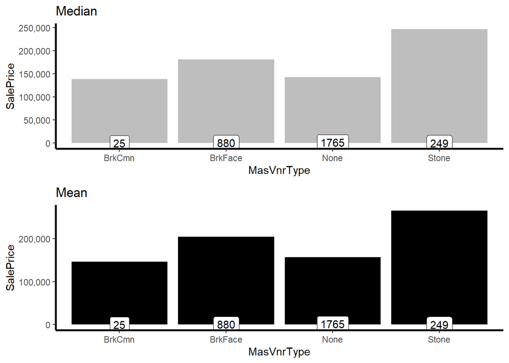

```r
all$MasVnrType[is.na(all$MasVnrType)] <- 'None'

grid.arrange(
  ggplot(all, aes(x=MasVnrType, y=SalePrice)) +
    stat_summary(geom ='bar', fun = "median", fill='grey')+
    scale_y_continuous(labels = comma) +
    geom_label(stat = "count",aes(label = ..count..,y = ..count..)) +
    GGvisualize_theme() +
    ggtitle("Median"),
  ggplot(all, aes(x=MasVnrType, y=SalePrice)) +
    stat_summary(geom ='bar', fun = "mean", fill='black')+
    scale_y_continuous(labels = comma) +
    geom_label(stat = "count",aes(label = ..count..,y = ..count..)) +
    GGvisualize_theme() +
    ggtitle("Mean"),
  nrow = 2 ,ncol = 1
)
```

從平均和中位數來看,Brick Common和None似乎在銷售價格上很接近,這邊假設普通石造牆壁和木製一樣便宜, 那這樣我們就把BrkCmn和None合併起來,就能把MasVnrType變數弄成次序的。

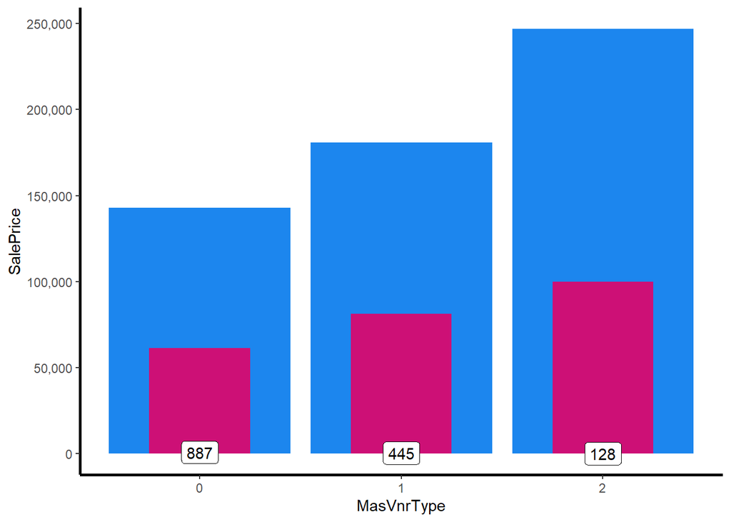

```r
all$MasVnrType<-as.integer(plyr::revalue(all$MasVnrType,
                                         c('None'=0, 'BrkCmn'=0,
                                           'BrkFace'=1, 'Stone'=2)))
all %>%
  filter(!(is.na(SalePrice))) %>%
  ggplot( aes(x=MasVnrType, y=SalePrice)) +
  stat_summary(geom ='bar', fun = "median", fill='dodgerblue2') +
  stat_summary(geom ='bar', fun = "sd", fill='deeppink3',width = 0.5) +
  scale_y_continuous(labels = comma) +
  geom_label(stat = "count",aes(label = ..count..,y = ..count..)) +
  GGvisualize_theme()
```

##### MasVnrArea

```r
all$MasVnrArea[is.na(all$MasVnrArea)] <- 0
```

#### MSZoning

- A Agriculture
- C Commercial
- FV Floating Village Residential
- I Industrial
- RH Residential High Density
- RL Residential Low Density
- RP Residential Low Density Park
- RM Residential Medium Density

因為這個變數是土地的分區，有商業區農業區工業區等等,我覺得應該跟Neighborhood有關連。

```r
all %>%
  group_by(MSZoning,Neighborhood) %>%
  summarise(value = n()) %>%
  xtabs(data = .,value~.) %>%
  kable() %>%
  scroll_box(width = '100%')
```

|  | Blmngtn | Blueste | BrDale | BrkSide | ClearCr | CollgCr | Crawfor | Edwards | Gilbert | IDOTRR | MeadowV | Mitchel | NAmes | NoRidge | NPkVill | NridgHt | NWAmes | OldTown | Sawyer | SawyerW | Somerst | StoneBr | SWISU | Timber | Veenker |
| --- | --- | --- | --- | --- | --- | --- | --- | --- | --- | --- | --- | --- | --- | --- | --- | --- | --- | --- | --- | --- | --- | --- | --- | --- | --- |
| C (all) | 0 | 0 | 0 | 0 | 0 | 0 | 0 | 0 | 0 | 22 | 0 | 0 | 0 | 0 | 0 | 0 | 0 | 2 | 0 | 0 | 0 | 0 | 1 | 0 | 0 |
| FV | 0 | 0 | 0 | 0 | 0 | 0 | 0 | 0 | 0 | 0 | 0 | 0 | 0 | 0 | 0 | 0 | 0 | 0 | 0 | 0 | 139 | 0 | 0 | 0 | 0 |
| RH | 0 | 0 | 0 | 0 | 0 | 0 | 2 | 2 | 0 | 0 | 0 | 0 | 7 | 0 | 0 | 0 | 0 | 0 | 0 | 6 | 0 | 0 | 9 | 0 | 0 |
| RL | 25 | 0 | 0 | 43 | 44 | 253 | 91 | 180 | 165 | 0 | 0 | 104 | 436 | 71 | 23 | 165 | 131 | 39 | 148 | 119 | 43 | 51 | 38 | 72 | 24 |
| RM | 3 | 10 | 30 | 65 | 0 | 14 | 10 | 12 | 0 | 68 | 37 | 9 | 0 | 0 | 0 | 1 | 0 | 198 | 3 | 0 | 0 | 0 | 0 | 0 | 0 |

```r
all[all$MSZoning %>% is.na(),c('SalePrice','MSZoning', 'Neighborhood',"OverallQual")]
```

```
##      SalePrice MSZoning Neighborhood OverallQual
## 1916        NA     <NA>       IDOTRR           2
## 2217        NA     <NA>       IDOTRR           1
## 2251        NA     <NA>       IDOTRR           5
## 2905        NA     <NA>      Mitchel           1
```

4個NA有三個是IDOTRR區一個是Mitchel區。

```r
#IDOTRR
filter(all,Neighborhood == "IDOTRR",OverallQual<=5)$MSZoning %>% table
```

```
## .
## C (all)      RM
##      22      40
```

```r
#Mitchel
filter(all,Neighborhood == "Mitchel",OverallQual<=5)$MSZoning %>% table
```

```
## .
## RL
## 63
```

2905將用RL填補，1916 2217 2251因為IDOTRR可能為商業區遺失的資料三筆OverallQual差距有點大，下面我視覺化IDOTRR的SalePrice、MSZoning和OverallQual。

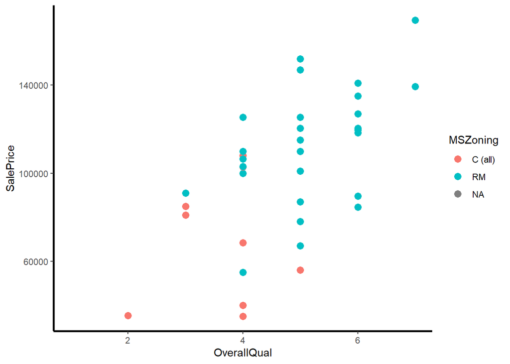

```r
all %>%
  filter(Neighborhood == 'IDOTRR') %>%
  ggplot(aes(x = OverallQual,y = SalePrice,color = MSZoning)) +
  geom_point(size = 3) +
  GGvisualize_theme()
```

1916 2217 因為OverallQual比較低我會填補C(all)回去，2251則填補RM回去。

```r
all[c(2251),"MSZoning"] <- "RM"
all[c(1916,2217),"MSZoning"] <- "C (all)"
all[2905,"MSZoning"] <- "RL"
all$MSZoning %<>% as.factor()
```

#### Kitchen

```r
names(all)[names(all) %>% str_detect("Kitchen") %>% which]
```

```
## [1] "KitchenAbvGr" "KitchenQual"
```

```r
na_col[names(na_col) %>% str_detect("Kitchen") %>% which]
```

```
## KitchenQual
##           1
```

##### KitchenQual

- Ex Excellent
- Gd Good
- TA Typical/Average
- Fa Fair
- Po Poor

```r
table(all$KitchenQual)
```

```
##
##   Ex   Fa   Gd   TA
##  205   70 1151 1492
```

```r
all$KitchenQual[is.na(all$KitchenQual)] <- 'TA' #將最多的填補回去
all$KitchenQual<-as.integer(plyr::revalue(all$KitchenQual,
                                          c('None' = 0, 'Po' = 1, 'Fa' = 2,
                                            'TA' = 3,'Gd' = 4, 'Ex' = 5)))
```

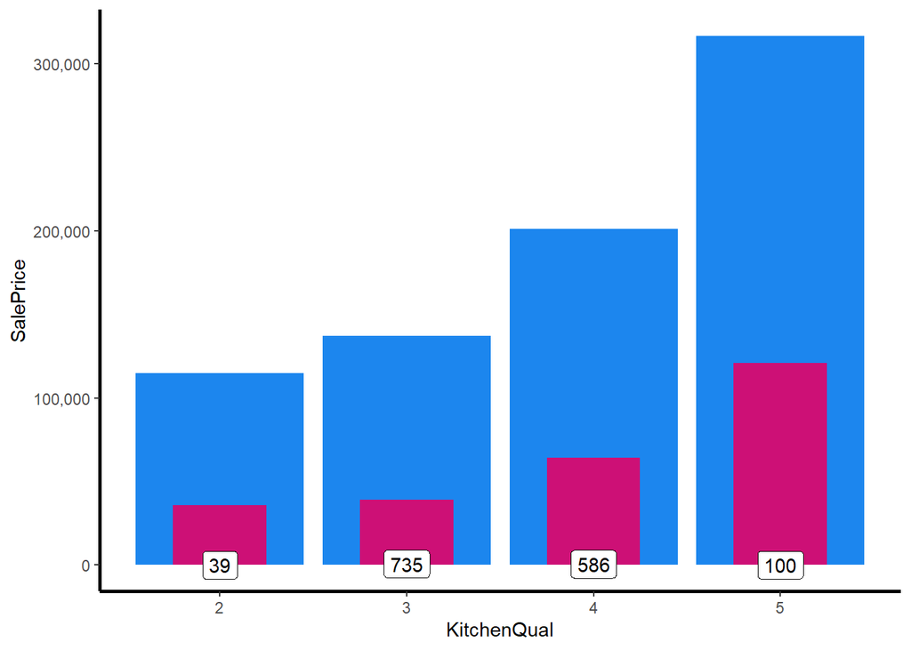

```r
all %>%
  filter(!(is.na(SalePrice))) %>%
  ggplot( aes(x=KitchenQual, y=SalePrice)) +
  stat_summary(geom ='bar', fun = "median", fill='dodgerblue2') +
  stat_summary(geom ='bar', fun = "sd", fill='deeppink3',width = 0.5) +
  scale_y_continuous(labels = comma) +
  geom_label(stat = "count",aes(label = ..count..,y = ..count..)) +
  GGvisualize_theme()
```

#### Utilities

```r
table(all$Utilities)
```

```
##
## AllPub NoSeWa
##   2916      1
```

變數因子嚴重不平衡,這變數對預測沒甚麼幫助,所以就剔除掉

```r
all$Utilities <- NULL
```

#### Functional

- Typ Typical Functionality
- Min1 Minor Deductions 1
- Min2 Minor Deductions 2
- Mod Moderate Deductions
- Maj1 Major Deductions 1
- Maj2 Major Deductions 2
- Sev Severely Damaged
- Sal Salvage only

```r
na_col[names(na_col) %>% str_detect("Functional") %>% which]
```

```
## Functional
##          2
```

```r
table(all$Functional)
```

```
##
## Maj1 Maj2 Min1 Min2  Mod  Sev  Typ
##   19    9   65   70   35    2 2717
```

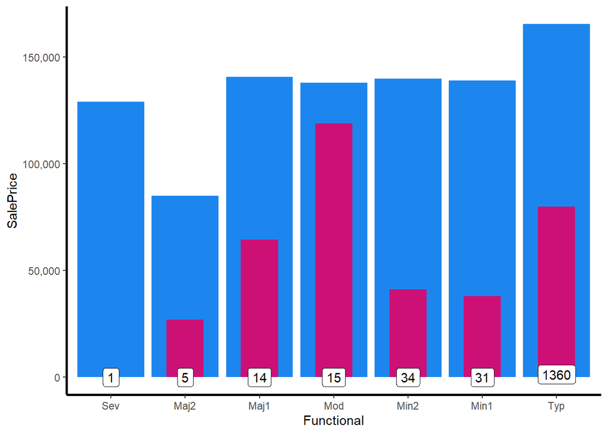

```r
#眾數填補
all$Functional[is.na(all$Functional)] <- names(sort(-table(all$Functional)))[1]
all %>%
  filter(!(is.na(SalePrice))) %>%
  ggplot( aes(x=factor(Functional,
                       levels =  c('Sal','Sev',
                                   'Maj2','Maj1',
                                   'Mod','Min2',
                                   'Min1','Typ')),
              y=SalePrice)) +
  stat_summary(geom ='bar', fun = "median", fill='dodgerblue2') +
  stat_summary(geom ='bar', fun = "sd", fill='deeppink3',width = 0.5) +
  scale_y_continuous(labels = comma) +
  xlab('Functional') +
  geom_label(stat = "count",aes(label = ..count..,y = ..count..)) +
  GGvisualize_theme()
```

看起來沒辦法轉成次序，且Min1&Min2看起來沒甚麼差，Maj1和Mod看起來也沒甚麼差但是Mod組內標準差太高了我不敢將它跟Maj1合併，這個變數就把Min1&Min2合併成Min然後轉成factor吧。

```r
all$Functional <-
  ifelse(all$Functional %in% c('Min2','Min1'),
         'Min',all$Functional)
all$Functional %<>% as.factor()
```

#### Exter

```r
names(all)[names(all) %>% str_detect("Exter") %>% which]
```

```
## [1] "Exterior1st" "Exterior2nd" "ExterQual"   "ExterCond"
```

```r
na_col[names(na_col) %>% str_detect("Exterior") %>% which]
```

```
## Exterior1st Exterior2nd
##           1           1
```

##### Exterior1st

- AsbShng Asbestos Shingles
- AsphShn Asphalt Shingles
- BrkComm Brick Common
- BrkFace Brick Face
- CBlock Cinder Block
- CemntBd Cement Board
- HdBoard Hard Board
- ImStucc Imitation Stucco
- MetalSd Metal Siding
- Other Other
- Plywood Plywood
- PreCast PreCast
- Stone Stone
- Stucco Stucco
- VinylSd Vinyl Siding
- Wd Sdng Wood Siding
- WdShing Wood Shingles

```r
#眾數填補
all$Exterior1st[is.na(all$Exterior1st)] <- names(sort(-table(all$Exterior1st)))[1]
all$Exterior1st <- as.factor(all$Exterior1st)
table(all$Exterior1st)
```

```
##
## AsbShng AsphShn BrkComm BrkFace  CBlock CemntBd HdBoard ImStucc MetalSd Plywood
##      44       2       6      87       2     126     442       1     450     221
##   Stone  Stucco VinylSd Wd Sdng WdShing
##       2      43    1026     411      56
```

##### Exterior2nd

同Exterior1st

```r
all$Exterior2nd[is.na(all$Exterior2nd)] <- names(sort(-table(all$Exterior2nd)))[1]
all$Exterior2nd <- as.factor(all$Exterior2nd)
table(all$Exterior2nd)
```

```
##
## AsbShng AsphShn Brk Cmn BrkFace  CBlock CmentBd HdBoard ImStucc MetalSd   Other
##      38       4      22      47       3     126     406      15     447       1
## Plywood   Stone  Stucco VinylSd Wd Sdng Wd Shng
##     270       6      47    1015     391      81
```

##### ExterQual

- Ex Excellent
- Gd Good
- TA Average/Typical
- Fa Fair
- Po Poor

```r
all$ExterQual <- as.integer(plyr::revalue(all$ExterQual,
                            c('None' = 0, 'Po' = 1, 'Fa' = 2,
                              'TA' = 3,'Gd' = 4, 'Ex' = 5)))
```

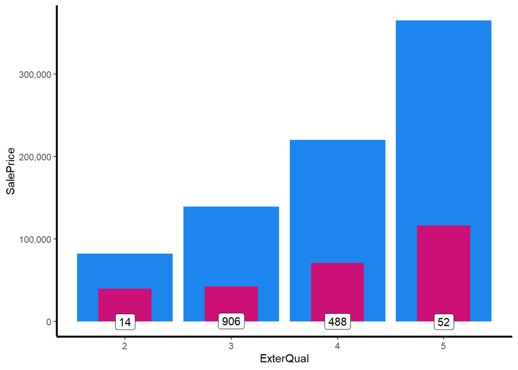

```r
all %>%
  filter(!(is.na(SalePrice))) %>%
  ggplot( aes(x=ExterQual, y=SalePrice)) +
  stat_summary(geom ='bar', fun = "median", fill='dodgerblue2') +
  stat_summary(geom ='bar', fun = "sd", fill='deeppink3',width = 0.5) +
  scale_y_continuous(labels = comma) +
  geom_label(stat = "count",aes(label = ..count..,y = ..count..)) +
  GGvisualize_theme()
```